# Craft beer: EDA and predictions using caret and vtreat

Will Canniford

## Introduction

I’ll start by showing column information that was given with the data set. There are some missing descriptions so I will investigate further once I have loaded the data in and we can have a look ourselves.

### Beer data

**abv**: The alcoholic content by volume with 0 being no alcohol and 1 being pure alcohol  
**ibu**: International bittering units, which describe how bitter a drink is  
**name**: The name of the beer  
**style**: Beer style (lager, ale, IPA, etc.)  
**brewery_id**: Unique identifier for brewery that produces this beer  
**ounces**: Size of beer in ounces

### Breweries data

**brewery_id**: Unique identifier for brewery that produces this beer  
**name**: Name of the brewery  
**city**: City that the brewery is located in  
**state**: State that the brewery is located in

Immediately, it looks like we have a key that we could use to join the two tables together: `brewery_id`.

## Reading and cleaning the data

I’ll read in the two tables.

```r
beers <- read_csv('./input/beers.csv')
breweries <- read_csv('./input/breweries.csv')
```

Let’s have a closer look at the structure of the data.

```r
glimpse(beers)
```

```
## Observations: 2,410
## Variables: 8
## $ X1         <int> 0, 1, 2, 3, 4, 5, 6, 7, 8, 9, 10, 11, 12, 13, 14, 1...
## $ abv        <dbl> 0.050, 0.066, 0.071, 0.090, 0.075, 0.077, 0.045, 0....
## $ ibu        <dbl> NA, NA, NA, NA, NA, NA, NA, NA, NA, NA, NA, NA, NA,...
## $ id         <int> 1436, 2265, 2264, 2263, 2262, 2261, 2260, 2259, 225...
## $ name       <chr> "Pub Beer", "Devil's Cup", "Rise of the Phoenix", "...
## $ style      <chr> "American Pale Lager", "American Pale Ale (APA)", "...
## $ brewery_id <int> 408, 177, 177, 177, 177, 177, 177, 177, 177, 177, 1...
## $ ounces     <dbl> 12.0, 12.0, 12.0, 12.0, 12.0, 12.0, 12.0, 12.0, 12....
```

#### Mystery columns

We can see that we have two columns that we don’t have prior information for. Let’s delve into these first and see whether we can work out what information they hold, if any.

```r
# How many rows are there in the data?
print(nrow(beers))
```

```
## [1] 2410
```

```r
# Let's see a summary for the unknown column
summary(beers$X1)
```

```
##    Min. 1st Qu.  Median    Mean 3rd Qu.    Max.
##     0.0   602.2  1204.5  1204.5  1806.8  2409.0
```

```r
# Let's check that they are all integers
table(beers$X1 == as.integer(beers$X1))
```

```
##
## TRUE
## 2410
```

```r
# How many unique values are there in the column?
length(unique(beers$X1))
```

```
## [1] 2410
```

It looks to me as though this column `X1` is just an incremental counter for the data.

```r
# Let's view some details about the `id` column for the beers data
summary(beers$id)
```

```
##    Min. 1st Qu.  Median    Mean 3rd Qu.    Max.
##     1.0   808.2  1453.5  1431.1  2075.8  2692.0
```

```r
# Checking to see whether the column is entirely integers
table(beers$id == as.integer(beers$id))
```

```
##
## TRUE
## 2410
```

```r
# Check column length
length(unique(beers$id))
```

```
## [1] 2410
```

This `id` column has a similar role. It could act as a key to another data set, but we can’t be sure.

#### Breweries

```r
glimpse(breweries)
```

```
## Observations: 558
## Variables: 4
## $ X1    <int> 0, 1, 2, 3, 4, 5, 6, 7, 8, 9, 10, 11, 12, 13, 14, 15, 16...
## $ name  <chr> "NorthGate Brewing", "Against the Grain Brewery", "Jack'...
## $ city  <chr> "Minneapolis", "Louisville", "Framingham", "San Diego", ...
## $ state <chr> "MN", "KY", "MA", "CA", "CA", "SC", "CO", "MI", "MI", "M...
```

It looks like the `brewery_id` hasn’t been labelled as such and is indicated through the unnamed column at the beginning that has been given the default of `X1`. I could rename it, but instead I will explicitly specify when I join the data next.

Joining the two tables will get all the information in one place, and should remain fairly tidy with a beer observation representing a row in the final table.

### Joining the data

Before I join, I’ll just check that all the rows of beers have a `brewery_id`.

```r
# Check the number of NA values in each column
map_df(beers, ~ sum(is.na(.)))
```

| X1 | abv | ibu | id | name | style | brewery_id | ounces |
| --- | --- | --- | --- | --- | --- | --- | --- |
| 0 | 62 | 1005 | 0 | 0 | 5 | 0 | 0 |

That’s good, it seems we won’t be missing any `brewery_id` values, and therefore brewery information for our beers.

```r
beers_breweries <- beers %>%
  # We don't need these columns
  select(-X1, -id) %>%
  # Specify the columns to join on: left_hand_key = right_hand_key
  left_join(breweries, by = c('brewery_id' = 'X1'))

# View the final, joined, table
glimpse(beers_breweries)
```

```
## Observations: 2,410
## Variables: 9
## $ abv        <dbl> 0.050, 0.066, 0.071, 0.090, 0.075, 0.077, 0.045, 0....
## $ ibu        <dbl> NA, NA, NA, NA, NA, NA, NA, NA, NA, NA, NA, NA, NA,...
## $ name.x     <chr> "Pub Beer", "Devil's Cup", "Rise of the Phoenix", "...
## $ style      <chr> "American Pale Lager", "American Pale Ale (APA)", "...
## $ brewery_id <int> 408, 177, 177, 177, 177, 177, 177, 177, 177, 177, 1...
## $ ounces     <dbl> 12.0, 12.0, 12.0, 12.0, 12.0, 12.0, 12.0, 12.0, 12....
## $ name.y     <chr> "10 Barrel Brewing Company", "18th Street Brewery",...
## $ city       <chr> "Bend", "Gary", "Gary", "Gary", "Gary", "Gary", "Ga...
## $ state      <chr> "OR", "IN", "IN", "IN", "IN", "IN", "IN", "IN", "IN...
```

### Final clean of the data

You can see that when we joined the data it created two name columns. That is because a name column existed in both data frames when we joined, so `dplyr::left_join` adds a suffix so we know the origin of the column. The left hand data frame has a default suffix of `.x` (beers in our case) while the right hand side data has a default value of `.y` (breweries in our case). You can specify what you want these suffixes to be when you perform the join using the `suffix` argument as such:

```r
beers_breweries <- beers %>%
  select(-X1, -id) %>%
  left_join(breweries, by = c('brewery_id' = 'X1'),
            suffix = c('_beer', '_breweries')) # Specify the suffixes
```

Unfortunately this doesn’t give us full control over the column names, so instead of rejoining the data I’ll just rename the columns.

```r
beers_breweries <- beers_breweries %>%
  rename(beer = name.x, # beer name
         brewery = name.y) # brewery name
```

### Unit conversion

One last thing that I would like to do is to change some of the units to make them more intuitive for my understanding.  
`abv` would be easier to read if it was multiplied up, and `ounces` isn’t how I would normally measure beer (English) so I will create a new column with the conversion to milliliter so that if I ever have to use the quantity measure it will be in units that I have a better intuitive understanding of.

```r
beers_breweries <- beers_breweries %>%
  mutate(abv = abv * 100,
         ml = round(ounces * 28.4131, 2)) # 28.4131 ml per fluid ounce

glimpse(beers_breweries)
```

```
## Observations: 2,410
## Variables: 10
## $ abv        <dbl> 5.0, 6.6, 7.1, 9.0, 7.5, 7.7, 4.5, 6.5, 5.5, 8.6, 7...
## $ ibu        <dbl> NA, NA, NA, NA, NA, NA, NA, NA, NA, NA, NA, NA, NA,...
## $ beer       <chr> "Pub Beer", "Devil's Cup", "Rise of the Phoenix", "...
## $ style      <chr> "American Pale Lager", "American Pale Ale (APA)", "...
## $ brewery_id <int> 408, 177, 177, 177, 177, 177, 177, 177, 177, 177, 1...
## $ ounces     <dbl> 12.0, 12.0, 12.0, 12.0, 12.0, 12.0, 12.0, 12.0, 12....
## $ brewery    <chr> "10 Barrel Brewing Company", "18th Street Brewery",...
## $ city       <chr> "Bend", "Gary", "Gary", "Gary", "Gary", "Gary", "Ga...
## $ state      <chr> "OR", "IN", "IN", "IN", "IN", "IN", "IN", "IN", "IN...
## $ ml         <dbl> 340.96, 340.96, 340.96, 340.96, 340.96, 340.96, 340...
```

Ok, that looks good to me, let’s start the next section.

## Insights

### Breweries

#### By state

To answer the question *“Which state has the most breweries?”* we actually don’t need our new cleaned and joined data. We can just use the original breweries data that was provided to us.

Let’s start by just getting the top 20 states with the most breweries in them.

```r
top_20_states <- breweries %>%
  group_by(state) %>%
  summarise(n_breweries = n()) %>% # Count the number of breweries per state
  arrange(desc(n_breweries)) %>% # Sort the results
  top_n(20) # Take the top 20 rows
```

We can then plot these to make some more sense of the comparison between the states.

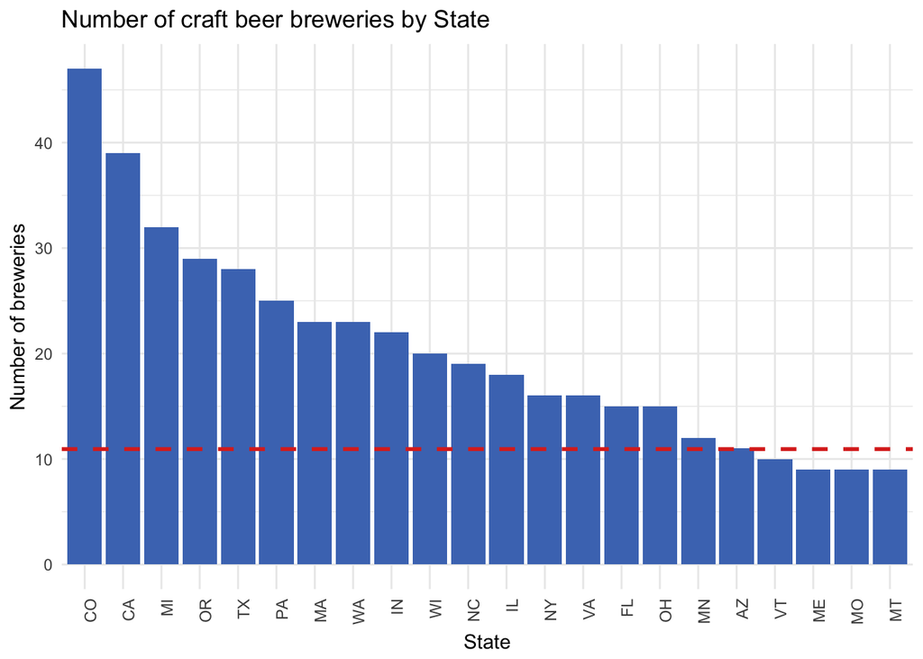

```r
# Calculate mean average number of breweries for use in graph
avg_breweries <- breweries %>%
  group_by(state) %>%
  summarise(n = n()) %>% # Summarise the first time by state
  summarise(mean = mean(n)) %>% # Summarise again to leave a single average value
  `$`(mean) # Return just that single value

ggplot(data = top_20_states, aes(x = reorder(state, -n_breweries), y = n_breweries)) +
  geom_col( fill = '#4B77BE') +
  geom_hline(yintercept = avg_breweries, color = '#DC3023', linetype = 2, size = 1) + # add horizontal line for average number
  theme_minimal() +
  labs(x = "State", y = "Number of breweries", title = "Number of craft beer breweries by State") +
  theme(axis.text.x = element_text(angle = 90, hjust = 1)) # rotate the axis text
```

#### By city

Which city would be the best to visit if you were going somewhere to find lots of craft beer?

```r
cities_count <- breweries %>%
  group_by(city) %>% # Group by city
  summarise(n_breweries = n()) %>% # Count per city
  arrange(desc(n_breweries)) %>% # Sort by count descending
  top_n(20) # Return the top 20 rows
```

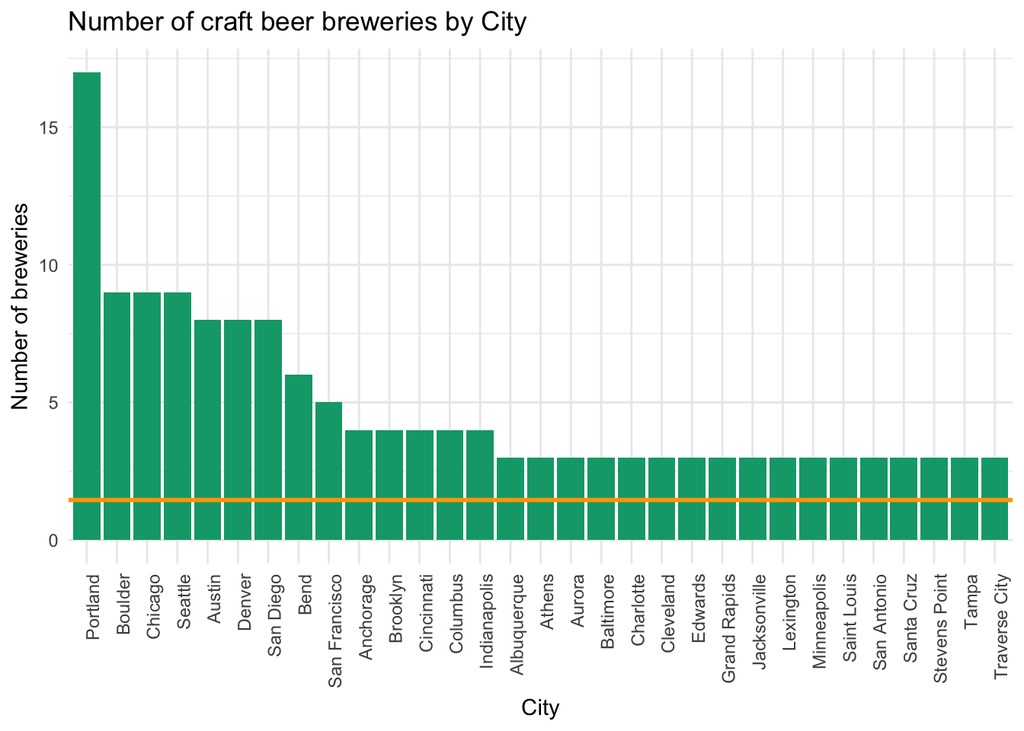

```r
# Calculate mean average number of breweries
avg_breweries_city <- breweries %>%
  group_by(city) %>%
  summarise(n = n()) %>%
  summarise(mean = mean(n)) %>%
  `$`(mean)

ggplot(data = cities_count, aes(x = reorder(city, -n_breweries), y = n_breweries)) +
  geom_col( fill = '#03A678') +
  geom_hline(yintercept = avg_breweries_city, color = '#FFA400', size = 1) + # add horizontal line for average number
  theme_minimal() +
  labs(x = "City", y = "Number of breweries", title = "Number of craft beer breweries by City") +
  theme(axis.text.x = element_text(angle = 90, hjust = 1)) # rotate the axis text
```

We can see here that Portland has the most breweries in any city; they are far out in front, shortly followed by Boulder, Chicago and Seattle. It should be noted that this data will only be representative of those cities that have at least one recorded craft beer brewery as we are using data for breweries rather than by city.

#### By alcohol content

Let’s have a look at those breweries that have a high alcohol content so you know where to go for your strong craft beer. I have limited the breweries to those that have produced more than 1 beer.

```r
high_abv <- beers_breweries %>%
  group_by(brewery) %>%
  summarise(avg_abv = mean(abv, na.rm = T), n_beers = n()) %>% # na.rm as some beers lack abv information
  filter(n_beers > 1) %>%
  arrange(desc(avg_abv)) %>%
  top_n(10, avg_abv) %>% # Top 10 rows based on avg_abv
  inner_join(breweries, by=c('brewery' = 'name')) %>%
  transmute(brewery, avg_abv, n_beers, location = paste(city, state, sep = ', ')) # Keep the relevant columns and join city and state to make a location variable

print(high_abv)
```

```
## # A tibble: 10 x 4
##    brewery                             avg_abv n_beers location
##    <chr>                                 <dbl>   <int> <chr>
##  1 SlapShot Brewing Company               8.35       2 Chicago, IL
##  2 Voodoo Brewery                         8.1        6 Meadville, PA
##  3 Hess Brewing Company                   8.07       3 San Diego, CA
##  4 Manzanita Brewing Company              8          5 Santee, CA
##  5 Redstone Meadery                       8          3 Boulder, CO
##  6 Oskar Blues Brewery (North Carol...    7.93       6 Brevard, NC
##  7 The Alchemist                          7.77       6 Waterbury, VT
##  8 Wingman Brewers                        7.7        2 Tacoma, WA
##  9 Marshall Wharf Brewing Company         7.62       5 Belfast, ME
## 10 Upslope Brewing Company                7.61      18 Boulder, CO
```

All of these breweries have a high average alcohol content for their beers. Perhaps if you’re looking for a strong craft beer you should head to Boulder that boasts two of the strongest craft brewers in the USA.

### State

#### Average alcohol content

Are there certain states that favour the stronger beers?

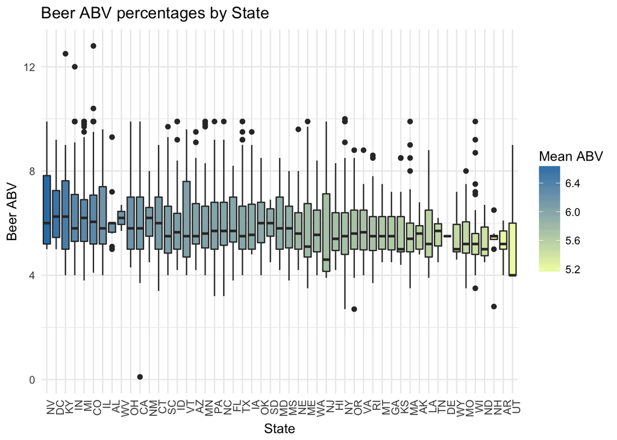

```r
beers_breweries %>%
  group_by(state) %>%
  mutate(mean_abv = mean(abv, na.rm = T)) %>%
ggplot(aes(x = reorder(state, -mean_abv), y = abv, fill = mean_abv)) +
  geom_boxplot() +
  labs(x = "State", y = "Beer ABV", title = "Beer ABV percentages by State") +
  scale_y_continuous(breaks = seq(0,12, 4)) +
  theme_minimal() +
  theme(axis.text.x = element_text(angle = 90, hjust = 1)) +
  scale_fill_continuous(low = '#edf8b1', high = '#2c7fb8', name = "Mean ABV")
```

Looks like the states with the strongest beers are Nevada, Washington DC and Kentucky.

### Beer style

#### Most popular

Let’s produce a graph that shows us the most popular beer style in the data.

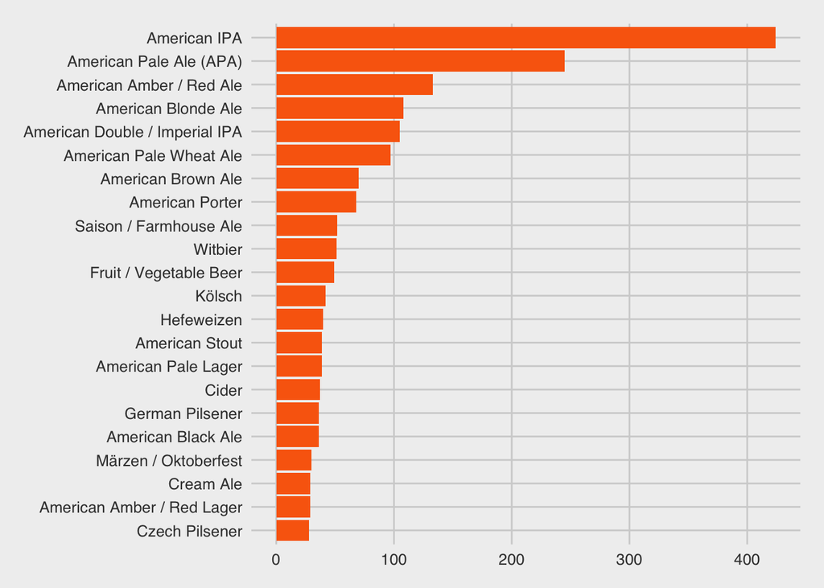

```r
beers_breweries %>%
  group_by(style) %>% # Group by the beer style
  summarise(count = n()) %>% # Count per group
  filter(count > 25) %>% # Only the larger groups
  ggplot(aes(reorder(style, count), count)) + # Reorder the bars
  geom_col(fill = '#F9690E') +
  theme_fivethirtyeight() +
  coord_flip()
```

It looks like the most popular craft beers are American IPA, APA and Red Ale in the medal positions.

#### By ABV

Let’s find out the strongest styles of those most popular beer styles, and just how strong those styles are.

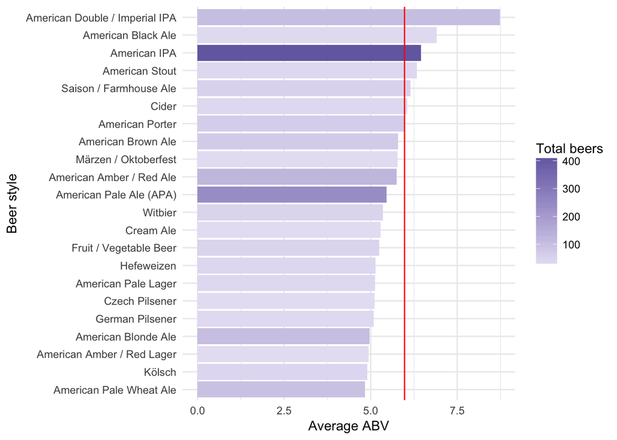

```r
avg_abv <- mean(beers_breweries$abv, na.rm = T)
beers_breweries %>%
  select(style, abv) %>%
  filter(complete.cases(.)) %>%
  group_by(style) %>%
  summarise(count = n(), mean_abv = mean(abv)) %>% filter(count > 25) %>%
  ggplot(aes(reorder(style, mean_abv), mean_abv)) + geom_col(aes(fill = count)) + theme_minimal() + coord_flip() + geom_hline(yintercept = avg_abv, color = 'red') + scale_fill_continuous(low = '#e7e3f4', high= '#756bb1', name = 'Total beers') + labs(y = 'Average ABV', x = 'Beer style')
```

American Double / Imperial IPA appears to be the strongest on average quite comfortably, with the average strength of the craft beers being pulled up by the most popular style, American IPA.

### ABV vs. IBU

Let’s have a quick look at the relationship between two of our numeric variables: `ibu` and `avb` which represent bitterness and alcohol content.

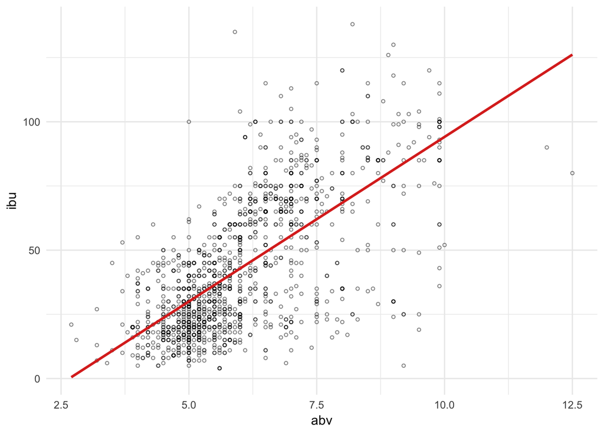

```r
beers_breweries %>%
  select(ibu, abv) %>%
  filter(complete.cases(.)) %>%
  ggplot(aes(abv, ibu)) +
  geom_point(alpha = .5, shape = 1, size = 1) +
  geom_smooth(method = lm, color = '#DC3023', se = FALSE, size = 1) +
  theme_minimal()
```

There seems to be a fairly clear relationship between `ibu` and `abv` for those beers where both the measures are available.

## Predicting ABV using `caret`

I am keen to build some models to see if we can predict the ABV of a beer based on some of the other features or information that is provided in these data sets.

If we run a summary on the response variable ABV, then we can see that there are some missing values for those which will have to be removed before we train our model.

I will start by looking at the numeric values. I imagine that improves may be able to be made by using categorical variables but with such a high number of categories in each variable I will leave it for now.

```r
# Let's see if ABV has any NA values
summary(beers$abv)
```

```
##    Min. 1st Qu.  Median    Mean 3rd Qu.    Max.    NA's
## 0.00100 0.05000 0.05600 0.05977 0.06700 0.12800      62
```

### Random Forest

Using random forest with `caret` and `ranger` to predict the ABV of beers.

```r
beers_with_abv <- beers %>%
  filter(!is.na(abv), !is.na(ibu), !is.na(ounces)) # Keep only complete cases

set.seed(1) # Set the seed
model <- train(abv ~ ibu + ounces, # Define our formula
               data = beers_with_abv,
               method = 'ranger', # Random forest package
               trControl = trainControl(method = 'cv', number = 10, verboseIter = TRUE)) # Cross validation to provide better indication of out-of-sample error
```

We can have an initial look at the model through the print method.

```r
print(model)
```

```
## Random Forest
##
## 1405 samples
##    2 predictor
##
## No pre-processing
## Resampling: Cross-Validated (10 fold)
## Summary of sample sizes: 1263, 1264, 1265, 1263, 1265, 1265, ...
## Resampling results across tuning parameters:
##
##   splitrule   RMSE        Rsquared   MAE
##   variance    0.01044505  0.4203535  0.007489215
##   extratrees  0.01037703  0.4264308  0.007453489
##
## Tuning parameter 'mtry' was held constant at a value of 2
## Tuning
##  parameter 'min.node.size' was held constant at a value of 5
## RMSE was used to select the optimal model using the smallest value.
## The final values used for the model were mtry = 2, splitrule =
##  extratrees and min.node.size = 5.
```

The RMSE is around 1% ABV per beer.

Just looking at the results can make it difficult to judge whether the model has gone a good job or not, so let’s have a look at plotting them to see whether we can gain a little more insight there.

What are the best ways to visualise a model that you have built? I will plot the predicted values against the true values to see how well the model fit with an abline.

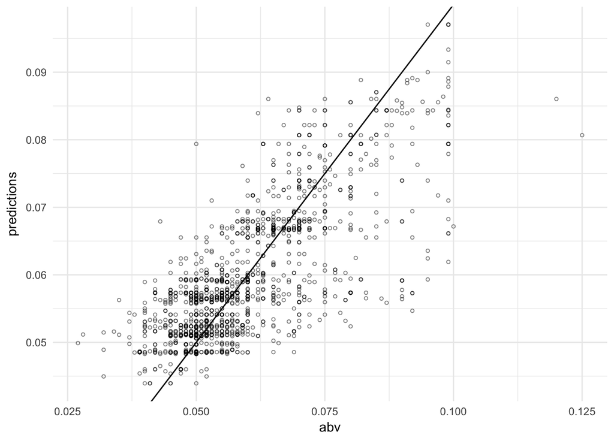

```r
beers_with_abv %>%
  select(abv, ibu, ounces, predictions) %>%
  ggplot(aes(abv, predictions)) +
  geom_point(alpha = .5, shape = 1, size = 1) + geom_abline() +
  theme_minimal()
```

### Linear model

Let’s have a look and see whether a linear model is more effective.

```r
linear_model <- train(abv ~ ibu + ounces,
                      data = beers_with_abv,
                      method = "lm", # Linear model method
                      trControl = trainControl(method = "cv", number = 10)) # Cross validation

print(linear_model)
```

```
## Linear Regression
##
## 1405 samples
##    2 predictor
##
## No pre-processing
## Resampling: Cross-Validated (10 fold)
## Summary of sample sizes: 1264, 1264, 1264, 1266, 1265, 1265, ...
## Resampling results:
##
##   RMSE        Rsquared   MAE
##   0.01002189  0.4573148  0.007177256
##
## Tuning parameter 'intercept' was held constant at a value of TRUE
```

Initially this model does appear to be slightly better than the random forest approach (keeping in mind that I haven’t done any forest tuning, so perhaps further improvements could be done).

```r
summary(linear_model)
```

```
##
## Call:
## lm(formula = .outcome ~ ., data = dat)
##
## Residuals:
##       Min        1Q    Median        3Q       Max
## -0.032473 -0.005893 -0.001592  0.003826  0.051037
##
## Coefficients:
##              Estimate Std. Error t value Pr(>|t|)
## (Intercept) 3.936e-02  1.665e-03  23.632  < 2e-16 ***
## ibu         3.488e-04  1.033e-05  33.756  < 2e-16 ***
## ounces      4.188e-04  1.190e-04   3.519 0.000447 ***
## ---
## Signif. codes:  0 '***' 0.001 '**' 0.01 '*' 0.05 '.' 0.1 ' ' 1
##
## Residual standard error: 0.01003 on 1402 degrees of freedom
## Multiple R-squared:  0.4546, Adjusted R-squared:  0.4538
## F-statistic: 584.2 on 2 and 1402 DF,  p-value: < 2.2e-16
```

We have had some improvements using the linear model that we have applied, but still a bad performance in the grand schemes of things.

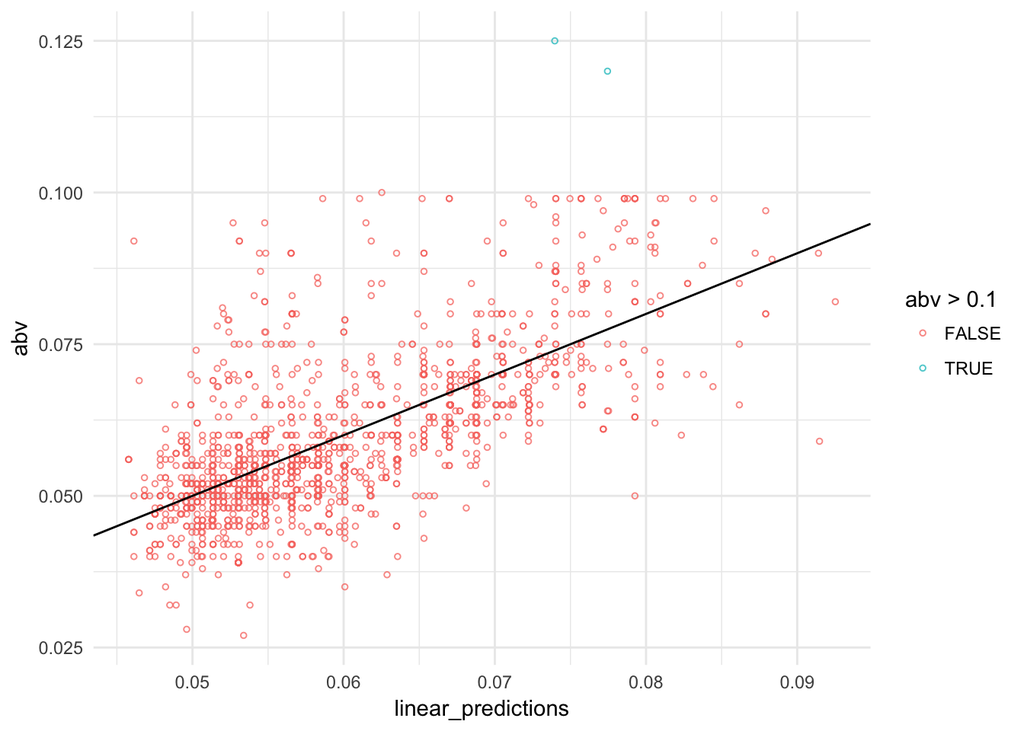

```r
# Predict using the linear model
beers_with_abv %>% mutate(linear_predictions = predict(linear_model, beers_with_abv)) %>%
ggplot(aes(linear_predictions, abv, col = abv > 0.10)) +
  geom_point(alpha = .75, shape = 1, size = 1) + geom_abline() +
  theme_minimal()
```

There are two outliers in the data where the beer is very strong (I have highlighted them above for your reference) which could improve our results if we were to remove them. Further investigation needed.

### Introducing categorical features with `vtreat`

We have only used two of the variables in the dataset so far, perhaps with the addition of some new features we will be able to improvement the performance of our model. We have gone through the main features of the data and seen that they are generally categorical.

Perhaps taking into consideration something like the beer type, or the location of manufacture would provide some extra insight and predictive power.

To do this I am going to use the `vtreat` package to one-hot encode the beer `style` variable; I will also keep the original `ibu` and `ounces` predictors that we have used in the previous models.

```r
library(vtreat) # Load the library

treatment_plan <- vtreat::designTreatmentsN(beers_with_abv,
                                            c('style', 'ounces', 'ibu'),
                                            outcomename = 'abv')
```

```
## [1] "vtreat 1.0.4 inspecting inputs Wed Jun 20 22:07:36 2018"
## [1] "designing treatments Wed Jun 20 22:07:36 2018"
## [1] " have initial level statistics Wed Jun 20 22:07:36 2018"
## [1] "design var style Wed Jun 20 22:07:36 2018"
## [1] "design var ounces Wed Jun 20 22:07:36 2018"
## [1] "design var ibu Wed Jun 20 22:07:36 2018"
## [1] " scoring treatments Wed Jun 20 22:07:36 2018"
## [1] "have treatment plan Wed Jun 20 22:07:36 2018"
## [1] "rescoring complex variables Wed Jun 20 22:07:36 2018"
## [1] "done rescoring complex variables Wed Jun 20 22:07:36 2018"
```

We have created a treatment plan that we can now use to prepare the dataframe for model building. The beer `style` variable has been split into levels with one column for each level of the variable.

`ounces` and `ibu` have been kept and marked as *clean* because they are complete. We can separate those variables that we want to keep by filtering the treatment plan to get those that are either *levels*, or *clean*.

```r
newvars <- treatment_plan %>%
  `$`(scoreFrame) %>%
  filter(code %in% c("clean", "lev")) %>%
           magrittr::use_series(varName)

(treated_beers_with_abv <- prepare(treatment_plan, beers_with_abv, varRestriction = newvars)) %>% head()
```

| ounces_clean | ibu_clean | style_lev_x.American.Amber…Red.Ale | style_lev_x.American.Blonde.Ale | style_lev_x.American.Brown.Ale | style_lev_x.American.Double…Imperial.IPA | style_lev_x.American.IPA | style_lev_x.American.Pale.Ale..APA. | style_lev_x.American.Pale.Wheat.Ale | style_lev_x.American.Porter | style_lev_x.Fruit…Vegetable.Beer | abv |
| --- | --- | --- | --- | --- | --- | --- | --- | --- | --- | --- | --- |
| 12.0 | 60 | 0 | 0 | 0 | 0 | 0 | 1 | 0 | 0 | 0 | 0.061 |
| 8.4 | 92 | 0 | 0 | 0 | 0 | 0 | 0 | 0 | 0 | 0 | 0.099 |
| 12.0 | 45 | 0 | 0 | 0 | 0 | 0 | 0 | 0 | 0 | 0 | 0.079 |
| 12.0 | 42 | 0 | 0 | 0 | 0 | 0 | 1 | 0 | 0 | 0 | 0.044 |
| 12.0 | 17 | 0 | 0 | 0 | 0 | 0 | 0 | 0 | 0 | 1 | 0.049 |
| 12.0 | 17 | 0 | 0 | 0 | 0 | 0 | 0 | 0 | 0 | 1 | 0.049 |

We now have a treated data set that we can use to, hopefully, improve our predictive power for `abv`.

```r
linear_model_treated <- train(abv ~ .,
                      data = treated_beers_with_abv,
                      method = "lm",
                      trControl = trainControl(method = "cv", number = 10))

print(linear_model_treated)
```

```
## Linear Regression
##
## 1405 samples
##   11 predictor
##
## No pre-processing
## Resampling: Cross-Validated (10 fold)
## Summary of sample sizes: 1263, 1265, 1265, 1264, 1265, 1265, ...
## Resampling results:
##
##   RMSE        Rsquared   MAE
##   0.00921506  0.5412836  0.006711859
##
## Tuning parameter 'intercept' was held constant at a value of TRUE
```

RMSE is down to **0.00921506**. We definitely seem to be moving in the right direction taking the beer style into consideration. This is made even more apparent when we look at the model summary.

```r
summary(linear_model_treated)
```

```
##
## Call:
## lm(formula = .outcome ~ ., data = dat)
##
## Residuals:
##       Min        1Q    Median        3Q       Max
## -0.029673 -0.005397 -0.000931  0.003912  0.048400
##
## Coefficients:
##                                              Estimate Std. Error t value
## (Intercept)                                 4.355e-02  1.587e-03  27.448
## ounces_clean                                2.655e-04  1.102e-04   2.409
## ibu_clean                                   3.601e-04  1.481e-05  24.320
## style_lev_x.American.Amber...Red.Ale       -2.994e-03  1.124e-03  -2.665
## style_lev_x.American.Blonde.Ale            -4.489e-03  1.252e-03  -3.585
## style_lev_x.American.Brown.Ale             -1.793e-05  1.547e-03  -0.012
## style_lev_x.American.Double...Imperial.IPA  6.824e-03  1.461e-03   4.670
## style_lev_x.American.IPA                   -6.669e-03  8.537e-04  -7.812
## style_lev_x.American.Pale.Ale..APA.        -8.209e-03  8.690e-04  -9.446
## style_lev_x.American.Pale.Wheat.Ale        -7.042e-03  1.253e-03  -5.622
## style_lev_x.American.Porter                 1.534e-03  1.529e-03   1.004
## style_lev_x.Fruit...Vegetable.Beer         -8.308e-04  1.747e-03  -0.476
##                                            Pr(>|t|)
## (Intercept)                                 < 2e-16 ***
## ounces_clean                               0.016129 *
## ibu_clean                                   < 2e-16 ***
## style_lev_x.American.Amber...Red.Ale       0.007796 **
## style_lev_x.American.Blonde.Ale            0.000349 ***
## style_lev_x.American.Brown.Ale             0.990751
## style_lev_x.American.Double...Imperial.IPA 3.30e-06 ***
## style_lev_x.American.IPA                   1.10e-14 ***
## style_lev_x.American.Pale.Ale..APA.         < 2e-16 ***
## style_lev_x.American.Pale.Wheat.Ale        2.27e-08 ***
## style_lev_x.American.Porter                0.315739
## style_lev_x.Fruit...Vegetable.Beer         0.634412
## ---
## Signif. codes:  0 '***' 0.001 '**' 0.01 '*' 0.05 '.' 0.1 ' ' 1
##
## Residual standard error: 0.00923 on 1393 degrees of freedom
## Multiple R-squared:  0.5414, Adjusted R-squared:  0.5378
## F-statistic: 149.5 on 11 and 1393 DF,  p-value: < 2.2e-16
```

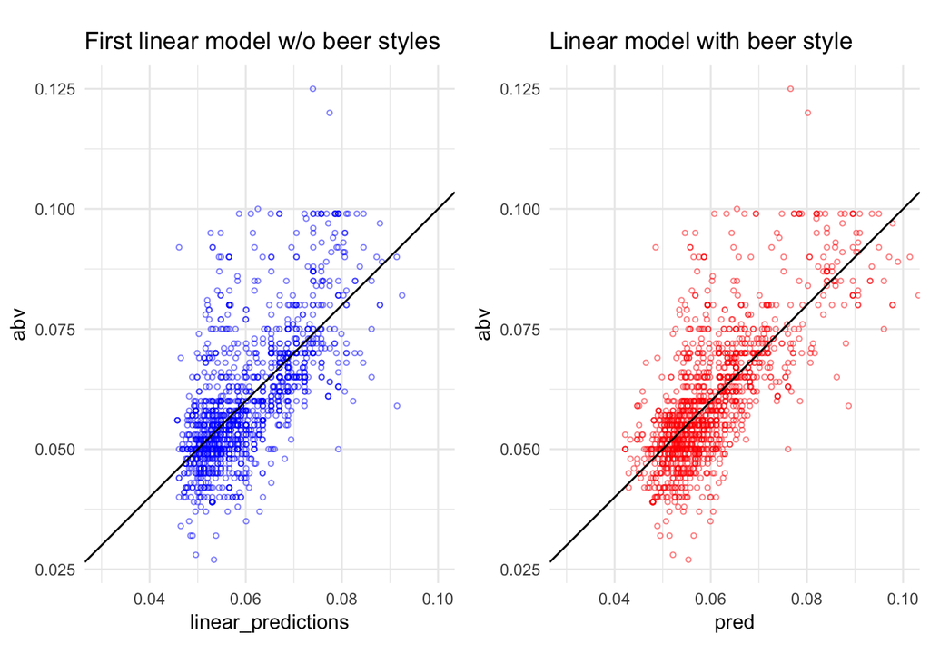

```r
treated_graph <- treated_beers_with_abv %>% mutate(pred = predict(linear_model_treated, treated_beers_with_abv)) %>%
ggplot(aes(pred, abv)) +
  geom_point(alpha = .5, shape = 1, size = 1, col = 'red') + geom_abline() +
  theme_minimal() +
  labs(title = "Linear model with beer style") +
  coord_equal(xlim = c(0.03, 0.1))

untreated_linear <- beers_with_abv %>% mutate(linear_predictions = predict(linear_model, beers_with_abv)) %>%
ggplot(aes(linear_predictions, abv)) +
  geom_point(alpha = .5, shape = 1, size = 1, col = 'blue') + geom_abline() +
  theme_minimal() +
  labs(title = "First linear model w/o beer styles") +
  coord_equal(xlim = c(0.03, 0.1))

library(gridExtra)
grid.arrange(untreated_linear, treated_graph, nrow = 1)
```

I feel like we can see that inclusion of beer styles to our linear model has *‘tightened’* up the predictions for the lower `abv` beers, but we appear to remain just as variable towards the higher percentage beers as when we weren’t including beer style in the model.

## Conclusions

- Colorado, California and Michigan are the states that contain the most craft beer breweries
- Portland is the busiest city for craft beer lovers and brewers
- Head to Boulder, CO to visit some of the strongest craft beer brewers around
- Nevada, Washington DC and Kentucky breweries brew the strongest craft beers
- American IPA is the most popular style of craft beer as well as one of the strongest on average
- American Double / Imperial IPA is the beer style for those that like their beer strong
- There appears to be a clear relationship between the bitterness and alcohol strength of these craft beers
- When predicting ABV using beer size and bitterness, linear model appears the most effective of those methods tried but more work needs to be done with the predictions and comparisons
- When we use the beer style as a predictor, we are able to improve our `abv` predictions further